# Practice Code: Day 3

Author

Constantin Manuel Bosancianu

Published

July 31, 2019

# 1 Introduction

We start as yesterday, by loading a few needed packages, and by defining a few custom functions we use below.

```r
library(pacman)
p_load(tidyverse, broom, ggeffects, texreg, arm, broom.mixed,
       interplot, knitr, kableExtra, magrittr, ggthemes)
```

We also define here a few helpful functions we will rely on in this code file.

```r
# Function from Zoltan Fazekas
fun_two_SD <- function(x) {
        (x - mean(x, na.rm = TRUE)) / (2 * sd(x, na.rm = TRUE))
}

fun_cent_noSD <- function(x) {
    x - mean(x, na.rm = TRUE)
}
```

# 2 Centering

So far, we have run models without centering any of the variables. Based on the lecture earlier, we now have the knowledge to start centering our predictors. Just a quick reminder: centering should always be done for predictors, irrespective of whether there is a cross-level interaction in the model or not:

- it will give a meaningful value to the intercept;
- it will speed up the ML-based estimation algorithm;
- more important, it will only estimate relationships between L1 predictors and the L1 outcome based on L1 variation, and not a mix of L1 and L2 variation.

Since this centering and standardization is done over and over again, it pays off to have a dedicated function for it: `fun_two_SD()` in the previous code chunk.

In my own applied work I use the Gelman method less often, as I find that some readers find it hard to switch between interpretations in the original scale and interpretations in SD-units. Additionally, I am typically not interested in assessing which variable has a stronger effect; if that is the case, I rely of predictions to show this. This is why I offer here a function only for centering: `fun_cent_noSD()` in the previous code chunk. You can use either one for your own purposes.

To keep things consistent with how Gelman and Hill discuss the topic, though, we will do centering and standardizing in this tutorial, though.

```r
df_issp <- readRDS("../02-data/01-ISSP.rds")

# Select needed variables from the data
df_issp %<>%
    dplyr::select(cnt, year, country, poleff, female,
                  age10, educ, urban, incquart, ti_cpi) %>%
    na.omit()

df_issp %<>%
    mutate(inc1 = if_else(incquart == 1, 1, 0),
           inc2 = if_else(incquart == 2, 1, 0),
           inc3 = if_else(incquart == 3, 1, 0),
           inc4 = if_else(incquart == 4, 1, 0))
```

In the code below, you might sometimes arrive at an error, informing you that you cannot compute the variance of a factor variable.[^1] If that happens, simply convert the factor variable into numeric.

<sup>1</sup> This comes into play in our `fun_two_SD()` function.

```r
df_issp %<>%
    group_by(cnt) %>% # groups ISSP data by country
    mutate(age10CWC = fun_two_SD(age10),
           educCWC = fun_two_SD(educ),
           femCWC = fun_two_SD(female),
           urbanCWC = fun_two_SD(urban),
           inc1CWC = fun_two_SD(inc1),
           inc2CWC = fun_two_SD(inc2),
           inc3CWC = fun_two_SD(inc3),
           inc4CWC = fun_two_SD(inc4))
```

Our L2 data was already supplied merged with L1 data, so it first needs to be aggregated back up at the country level, then centered, and then merged back in. Grand-mean centering (even though I’ve used `group_by()`, it doesn’t influence the centering after aggregating the values up at the country level).

```r
df_agg <- df_issp %>%
    group_by(cnt) %>% # groups ISSP by country
    summarise(ti_cpi = mean(ti_cpi, na.rm = TRUE)) %>%
    # Above, for each country compute mean of CPI (which is the CPI
    # value itself for that country). The "summarise()" function
    # generates one value of each country, so now you have each row
    # observation a separate country.
    mutate(cpiCGM = fun_two_SD(ti_cpi)) %>%
    # On this country-level data set, do centering of CPI
    dplyr::select(-ti_cpi) # Delete the uncentered version of CPI
```

Finally, we merge `df_agg` with `df_issp` using country as a matching indicator.[^2]

<sup>2</sup> This approach could easily extend to instances where you have to merge using multiple matching keys, such as country and year.

```r
df_issp <- left_join(df_issp, df_agg, by = c("cnt"))
rm(df_agg)
```

If the group-mean centering worked OK, the mean of the variable after centering in each of the groups should be 0.

```r
df_issp %>%
    group_by(cnt) %>%
    summarise(original = mean(age10, na.rm = TRUE),
              centered = mean(age10CWC, na.rm = TRUE),
              corr = cor(age10, age10CWC)) %>%
    kable(caption = "Testing centering worked",
          digits = 2,
          caption.above = TRUE,
          col.names = c("Country", "Original version", "Centered version",
                        "Correlation")) %>%
    kable_styling(full_width = FALSE)
```

Testing centering worked

| Country | Original version | Centered version | Correlation |
| --- | --- | --- | --- |
| AT | 4.99 | 0 | 1 |
| AU | 5.38 | 0 | 1 |
| BE | 4.59 | 0 | 1 |
| CH | 4.97 | 0 | 1 |
| CL | 4.87 | 0 | 1 |
| CZ | 5.26 | 0 | 1 |
| DE | 4.96 | 0 | 1 |
| DK | 4.79 | 0 | 1 |
| EE | 4.49 | 0 | 1 |
| ES | 4.99 | 0 | 1 |
| FI | 4.73 | 0 | 1 |
| FR | 5.14 | 0 | 1 |
| GB | 5.24 | 0 | 1 |
| GE | 4.85 | 0 | 1 |
| HR | 4.60 | 0 | 1 |
| IL | 4.98 | 0 | 1 |
| IN | 4.04 | 0 | 1 |
| IS | 4.83 | 0 | 1 |
| JP | 5.32 | 0 | 1 |
| KR | 4.53 | 0 | 1 |
| LT | 5.05 | 0 | 1 |
| NL | 5.49 | 0 | 1 |
| NO | 4.99 | 0 | 1 |
| NZ | 5.40 | 0 | 1 |
| PH | 4.31 | 0 | 1 |
| PL | 5.09 | 0 | 1 |
| RU | 4.82 | 0 | 1 |
| SE | 5.11 | 0 | 1 |
| SI | 5.29 | 0 | 1 |
| SK | 4.86 | 0 | 1 |
| TR | 3.98 | 0 | 1 |
| TW | 4.54 | 0 | 1 |
| US | 4.84 | 0 | 1 |
| VE | 3.79 | 0 | 1 |
| ZA | 4.33 | 0 | 1 |

# 3 Multilevel model: random slopes

The last model we tested yesterday was the one below, though now we will do it with and without the centered versions of the variables.

```r
mlm.uncent <- lmer(poleff ~ 1 + age10 + female + educ + urban +
                     inc2 + inc3 + inc4 + ti_cpi +
                     (1 | cnt),
                   data = df_issp,
                   control = lmerControl(optimizer = "bobyqa"))

mlm.cent <- lmer(poleff ~ 1 + age10CWC + femCWC + educCWC +
                   urbanCWC + inc2CWC + inc3CWC + inc4CWC + cpiCGM +
                   (1 | cnt),
                 data = df_issp,
                 control = lmerControl(optimizer = "bobyqa"))

htmlreg(list(mlm.uncent, mlm.cent),
        digits = 3,
        custom.model.names = c("Uncentered predictors",
                               "Centered predictors"),
        caption = "Comparison of 2 multilevel specifications",
        caption.above = TRUE,
        custom.coef.map = list("(Intercept)" = "Intercept",
                               "age10" = "Age (in decades)",
                               "female" = "Gender (woman)",
                               "educ" = "Education",
                               "urban" = "Urban settlement",
                               "inc2" = "2nd income quartile",
                               "inc3" = "3rd income quartile",
                               "inc4" = "4th income quartile",
                               "ti_cpi" = "Corruption perceptions index",
                               "age10CWC" = "Age (in decades)",
                               "femCWC" = "Gender (woman)",
                               "educCWC" = "Education",
                               "urbanCWC" = "Urban settlement",
                               "inc2CWC" = "2nd income quartile",
                               "inc3CWC" = "3rd income quartile",
                               "inc4CWC" = "4th income quartile",
                               "cpiCGM" = "Corruption perceptions index"),
        single.row = FALSE,
        inline.css = TRUE,
        html.tag = FALSE,
        head.tag = FALSE,
        body.tag = FALSE)
```

Comparison of 2 multilevel specifications

|  | Uncentered predictors | Centered predictors |
| --- | --- | --- |
| Intercept | 1.871*** | 2.963*** |
|  | (0.165) | (0.045) |
| Age (in decades) | 0.036*** | 0.123*** |
|  | (0.002) | (0.007) |
| Gender (woman) | -0.120*** | -0.120*** |
|  | (0.007) | (0.007) |
| Education | 0.041*** | 0.319*** |
|  | (0.001) | (0.008) |
| Urban settlement | 0.053*** | 0.043*** |
|  | (0.008) | (0.007) |
| 2nd income quartile | 0.072*** | 0.060*** |
|  | (0.010) | (0.009) |
| 3rd income quartile | 0.139*** | 0.116*** |
|  | (0.010) | (0.009) |
| 4th income quartile | 0.266*** | 0.224*** |
|  | (0.011) | (0.009) |
| Corruption perceptions index | 0.005* | 0.299** |
|  | (0.002) | (0.092) |
| AIC | 79061.104 | 78947.798 |
| BIC | 79154.994 | 79041.689 |
| Log Likelihood | -39519.552 | -39462.899 |
| Num. obs. | 37628 | 37628 |
| Num. groups: cnt | 35 | 35 |
| Var: cnt (Intercept) | 0.072 | 0.071 |
| Var: Residual | 0.475 | 0.474 |

***p < 0.001; **p < 0.01; *p < 0.05

```r
rm(mlm.uncent)
```

In this particular instance it didn’t make much of a difference whether we used the centered or uncentered predictors at the L1, but in other cases it can make a big difference. For our L2 predictor (corruption perceptions index) it actually made a noticeable difference.

## 3.1 Initial specification

Now we also allow the slope of education to randomly vary, producing a random (varying) intercept & random (varying) slope specification.

```r
mlm.2 <- lmer(poleff ~ 1 + age10CWC + femCWC + educCWC +
                  urbanCWC + inc2CWC + inc3CWC + inc4CWC + cpiCGM +
                  (1 + educCWC | cnt),
              data = df_issp,
              control = lmerControl(optimizer = "bobyqa"))
summary(mlm.2)
```

```
Linear mixed model fit by REML ['lmerMod']
Formula: poleff ~ 1 + age10CWC + femCWC + educCWC + urbanCWC + inc2CWC +
    inc3CWC + inc4CWC + cpiCGM + (1 + educCWC | cnt)
   Data: df_issp
Control: lmerControl(optimizer = "bobyqa")

REML criterion at convergence: 78724.3

Scaled residuals:
    Min      1Q  Median      3Q     Max
-4.2991 -0.6728 -0.0102  0.6698  8.7376

Random effects:
 Groups   Name        Variance Std.Dev. Corr
 cnt      (Intercept) 0.07161  0.2676
          educCWC     0.01360  0.1166   -0.26
 Residual             0.47063  0.6860
Number of obs: 37628, groups:  cnt, 35

Fixed effects:
             Estimate Std. Error t value
(Intercept)  2.963134   0.045388  65.284
age10CWC     0.121791   0.007488  16.264
femCWC      -0.120937   0.007118 -16.989
educCWC      0.322607   0.021337  15.120
urbanCWC     0.044429   0.007207   6.164
inc2CWC      0.057036   0.008775   6.500
inc3CWC      0.113778   0.008950  12.713
inc4CWC      0.218922   0.009302  23.534
cpiCGM       0.354558   0.089384   3.967

Correlation of Fixed Effects:
         (Intr) a10CWC femCWC edcCWC urbCWC in2CWC in3CWC in4CWC
age10CWC  0.000
femCWC    0.000  0.024
educCWC  -0.238  0.088 -0.003
urbanCWC  0.000 -0.007 -0.013 -0.052
inc2CWC   0.000  0.025  0.035 -0.036  0.005
inc3CWC   0.000  0.077  0.057 -0.065  0.002  0.515
inc4CWC   0.000  0.078  0.079 -0.105 -0.036  0.510  0.540
cpiCGM    0.000 -0.002 -0.001  0.000  0.000  0.000 -0.001 -0.001
```

```r
ranef(mlm.cent)
```

```
$cnt
    (Intercept)
AT -0.201283662
AU  0.161454722
BE -0.131178998
CH  0.217939316
CL -0.009347205
CZ -0.210563360
DE  0.053041575
DK  0.095056240
EE -0.188733217
ES -0.111356562
FI -0.101301190
FR  0.462996805
GB -0.029392188
GE -0.116492271
HR -0.276794618
IL -0.235354828
IN -0.021730593
IS  0.421775058
JP  0.041951586
KR -0.200900770
LT -0.368161308
NL  0.143233769
NO  0.337766370
NZ  0.102995533
PH  0.155467849
PL -0.363464197
RU  0.095659339
SE  0.115767916
SI -0.490871529
SK -0.253798566
TR  0.336164478
TW -0.048465435
US -0.007139511
VE  0.771415487
ZA -0.146356036

with conditional variances for "cnt"
```

```r
ranef(mlm.2) # You've added one more random effect in this
```

```
$cnt
   (Intercept)      educCWC
AT -0.21675962  0.096240600
AU  0.14078915 -0.061555813
BE -0.14923941  0.012697944
CH  0.18634085  0.070902450
CL -0.02161784  0.033287838
CZ -0.19075154  0.123665500
DE  0.03174445  0.104219777
DK  0.05620793  0.060047276
EE -0.19633502  0.007229771
ES -0.10491289  0.160063041
FI -0.13765580  0.178149756
FR  0.45667855 -0.026021728
GB -0.04890291  0.003722349
GE -0.09319103 -0.033681750
HR -0.25645598 -0.012284508
IL -0.22846116  0.029133406
IN  0.01588983 -0.318450280
IS  0.40099665 -0.057484159
JP  0.02585125 -0.132419677
KR -0.18658298  0.023156701
LT -0.35951430 -0.010032705
NL  0.11582388  0.162531314
NO  0.30631295  0.026355087
NZ  0.06536046 -0.105901507
PH  0.19546293 -0.204495665
PL -0.36069600 -0.060176488
RU  0.15097704 -0.007085090
SE  0.08270869  0.070761311
SI -0.47996007  0.098103861
SK -0.23213926  0.020040049
TR  0.37027486 -0.207707757
TW -0.04316137  0.068450766
US -0.02100835  0.071667672
VE  0.84141568 -0.046418547
ZA -0.11548964 -0.136710796

with conditional variances for "cnt"
```

```r
             # specification.
```

## 3.2 Variation in the slope

Plotting the variation in the effect of education (we did this yesterday for the intercept in a RI specification).

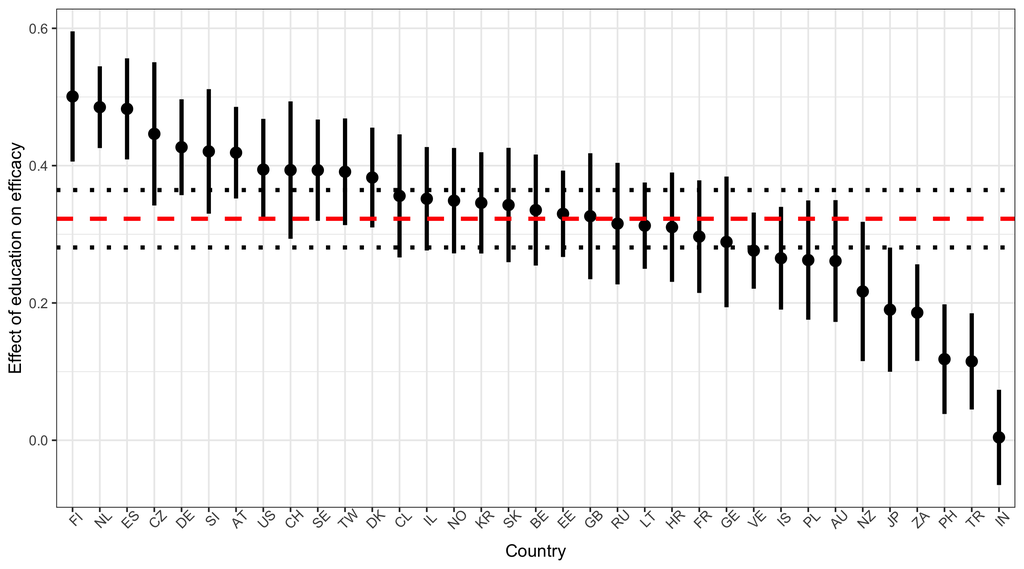

```r
ranef(mlm.2) %>%
    augment(ci.level = 0.95) %>%
    # Different way of writing augment(ranef(mlm.2), ci.level=0.95)
    filter(variable == "educCWC") %>%
    # Keep only random effects for education
    dplyr::select(level, estimate, std.error) %>%
    # Keep only columns identifying the country, the Beta, and SE
    rename(cnt = level) %>%
    mutate(estimate = estimate + fixef(mlm.2)["educCWC"]) %>%
    # Add fixed-effect to deviation from overall slope so as to get
    # the slope in each country
    ggplot(aes(x = reorder(cnt, -estimate),
               y = estimate)) +
    geom_point(size = 3) +
    labs(x = "Country",
         y = "Effect of education on efficacy") +
    theme_bw() +
    geom_errorbar(aes(ymin = estimate - 1.96*std.error,
                      ymax = estimate + 1.96*std.error),
                  linewidth = 1.25,
                  width = 0) +
    geom_hline(yintercept = fixef(mlm.2)["educCWC"],
               linewidth = 1.25,
               linetype = "dashed",
               color = "red") +
    geom_hline(yintercept = fixef(mlm.2)["educCWC"] +
                        1.96*se.fixef(mlm.2)["educCWC"],
               linewidth = 1.25,
               linetype = "dotted") +
    geom_hline(yintercept = fixef(mlm.2)["educCWC"] -
                        1.96*se.fixef(mlm.2)["educCWC"],
               linewidth = 1.25,
               linetype = "dotted") +
    theme(axis.text.x = element_text(angle = 45))
```

The red dashed line denotes the overall slope, while the dots and whiskers plot the group slopes. You could easily generate a similar plot for the varying intercepts, if you wanted to see what is going on.

You can easily see that you are estimating 3 random effects, as well as a correlation between L2 random effects. **R** estimates this by default, whereas **Stata** does not.[^3] If you want to suppress this additional parameter from being estimates, it takes a simple modification of the syntax.

<sup>3</sup> Keep this in mind if at some point you notice very slight differences in results between the two software packages.

```r
mlm.temp <- lmer(poleff ~ 1 + age10CWC + femCWC + educCWC +
                     urbanCWC + inc2CWC + inc3CWC + inc4CWC +
                     cpiCGM + (1 | cnt) + (0 + educCWC | cnt),
                 data = df_issp,
                 control = lmerControl(optimizer = "bobyqa"))
summary(mlm.temp)
```

```
Linear mixed model fit by REML ['lmerMod']
Formula: poleff ~ 1 + age10CWC + femCWC + educCWC + urbanCWC + inc2CWC +
    inc3CWC + inc4CWC + cpiCGM + (1 | cnt) + (0 + educCWC | cnt)
   Data: df_issp
Control: lmerControl(optimizer = "bobyqa")

REML criterion at convergence: 78725.9

Scaled residuals:
    Min      1Q  Median      3Q     Max
-4.3056 -0.6727 -0.0106  0.6694  8.7396

Random effects:
 Groups   Name        Variance Std.Dev.
 cnt      (Intercept) 0.07092  0.2663
 cnt.1    educCWC     0.01352  0.1163
 Residual             0.47063  0.6860
Number of obs: 37628, groups:  cnt, 35

Fixed effects:
             Estimate Std. Error t value
(Intercept)  2.963133   0.045172  65.597
age10CWC     0.121757   0.007489  16.258
femCWC      -0.120973   0.007119 -16.994
educCWC      0.322519   0.021286  15.152
urbanCWC     0.044504   0.007208   6.175
inc2CWC      0.057082   0.008775   6.505
inc3CWC      0.113860   0.008950  12.722
inc4CWC      0.219027   0.009303  23.544
cpiCGM       0.298659   0.091660   3.258

Correlation of Fixed Effects:
         (Intr) a10CWC femCWC edcCWC urbCWC in2CWC in3CWC in4CWC
age10CWC  0.000
femCWC    0.000  0.024
educCWC   0.000  0.088 -0.003
urbanCWC  0.000 -0.007 -0.013 -0.052
inc2CWC   0.000  0.025  0.035 -0.036  0.005
inc3CWC   0.000  0.077  0.057 -0.065  0.002  0.515
inc4CWC   0.000  0.078  0.079 -0.105 -0.036  0.510  0.540
cpiCGM    0.000  0.000  0.000  0.000  0.000  0.000  0.000  0.000
```

```r
rm(mlm.temp)
```

# 4 Cross-level interactions

Extend the specification by adding a predictor for the varying slope of education. The substantive implication of this is that you are now testing a hypothesis: that there is a systematic association between the magnitude of the effect of education on political efficacy, and the level of (perceived) corruption in the country.

## 4.1 Initial specification

```r
mlm.3 <- lmer(poleff ~ 1 + age10CWC + femCWC + educCWC +
                  urbanCWC + inc2CWC + inc3CWC + inc4CWC +
                  cpiCGM + educCWC * cpiCGM + (1 + educCWC | cnt),
              data = df_issp,
              control = lmerControl(optimizer = "bobyqa"))
summary(mlm.3)
```

```
Linear mixed model fit by REML ['lmerMod']
Formula: poleff ~ 1 + age10CWC + femCWC + educCWC + urbanCWC + inc2CWC +
    inc3CWC + inc4CWC + cpiCGM + educCWC * cpiCGM + (1 + educCWC |      cnt)
   Data: df_issp
Control: lmerControl(optimizer = "bobyqa")

REML criterion at convergence: 78721.9

Scaled residuals:
    Min      1Q  Median      3Q     Max
-4.3118 -0.6730 -0.0111  0.6698  8.7721

Random effects:
 Groups   Name        Variance Std.Dev. Corr
 cnt      (Intercept) 0.07093  0.2663
          educCWC     0.01092  0.1045   -0.24
 Residual             0.47063  0.6860
Number of obs: 37628, groups:  cnt, 35

Fixed effects:
                Estimate Std. Error t value
(Intercept)     2.963134   0.045175  65.592
age10CWC        0.121609   0.007487  16.243
femCWC         -0.121019   0.007118 -17.002
educCWC         0.322622   0.019457  16.581
urbanCWC        0.044439   0.007207   6.166
inc2CWC         0.057098   0.008774   6.507
inc3CWC         0.113780   0.008949  12.714
inc4CWC         0.218912   0.009302  23.535
cpiCGM          0.298754   0.091668   3.259
educCWC:cpiCGM  0.108146   0.038904   2.780

Correlation of Fixed Effects:
            (Intr) a10CWC femCWC edcCWC urbCWC in2CWC in3CWC in4CWC cpiCGM
age10CWC     0.000
femCWC       0.000  0.024
educCWC     -0.218  0.096 -0.003
urbanCWC     0.000 -0.007 -0.013 -0.057
inc2CWC      0.000  0.025  0.035 -0.039  0.005
inc3CWC      0.000  0.077  0.057 -0.071  0.002  0.515
inc4CWC      0.000  0.078  0.079 -0.115 -0.036  0.510  0.540
cpiCGM       0.000  0.000  0.000  0.000  0.000  0.000  0.000  0.000
edcCWC:cCGM  0.000 -0.009 -0.005  0.001  0.001  0.000 -0.003 -0.007 -0.221
```

A comparative view can easily show what has changed with each model.

```r
htmlreg(list(mlm.cent, mlm.2, mlm.3),
        digits = 3,
        custom.model.names = c("RI", "RI+RS",
                               "RI+RS & pred"),
        caption = "Comparison of 3 multilevel specifications",
        caption.above = TRUE,
        custom.coef.map = list("(Intercept)" = "Intercept",
                               "age10CWC" = "Age (in decades)",
                               "femCWC" = "Gender (woman)",
                               "educCWC" = "Education",
                               "urbanCWC" = "Urban settlement",
                               "inc2CWC" = "2nd income quartile",
                               "inc3CWC" = "3rd income quartile",
                               "inc4CWC" = "4th income quartile",
                               "cpiCWC" = "Corruption perceptions index",
                               "educCWC:cpiCGM" = "Education x Corruption perceptions"),
        single.row = FALSE,
        inline.css = TRUE,
        html.tag = FALSE,
        head.tag = FALSE,
        body.tag = FALSE)
```

Comparison of 3 multilevel specifications

|  | RI | RI+RS | RI+RS & pred |
| --- | --- | --- | --- |
| Intercept | 2.963*** | 2.963*** | 2.963*** |
|  | (0.045) | (0.045) | (0.045) |
| Age (in decades) | 0.123*** | 0.122*** | 0.122*** |
|  | (0.007) | (0.007) | (0.007) |
| Gender (woman) | -0.120*** | -0.121*** | -0.121*** |
|  | (0.007) | (0.007) | (0.007) |
| Education | 0.319*** | 0.323*** | 0.323*** |
|  | (0.008) | (0.021) | (0.019) |
| Urban settlement | 0.043*** | 0.044*** | 0.044*** |
|  | (0.007) | (0.007) | (0.007) |
| 2nd income quartile | 0.060*** | 0.057*** | 0.057*** |
|  | (0.009) | (0.009) | (0.009) |
| 3rd income quartile | 0.116*** | 0.114*** | 0.114*** |
|  | (0.009) | (0.009) | (0.009) |
| 4th income quartile | 0.224*** | 0.219*** | 0.219*** |
|  | (0.009) | (0.009) | (0.009) |
| Education x Corruption perceptions |  |  | 0.108** |
|  |  |  | (0.039) |
| AIC | 78947.798 | 78750.266 | 78749.860 |
| BIC | 79041.689 | 78861.228 | 78869.357 |
| Log Likelihood | -39462.899 | -39362.133 | -39360.930 |
| Num. obs. | 37628 | 37628 | 37628 |
| Num. groups: cnt | 35 | 35 | 35 |
| Var: cnt (Intercept) | 0.071 | 0.072 | 0.071 |
| Var: Residual | 0.474 | 0.471 | 0.471 |
| Var: cnt educCWC |  | 0.014 | 0.011 |
| Cov: cnt (Intercept) educCWC |  | -0.008 | -0.007 |

***p < 0.001; **p < 0.01; *p < 0.05

## 4.2 Present interaction effect

A few years ago graphically presenting such interaction effects was a more code-demanding task, as in involved manually specifying a range for the moderator variable, constructing a new data set, obtaining predicted values and uncertainty for them, and then plotting these quantities. Thankfully, dedicated packages and canned functions have appeared that can do this for you in a much faster and convenient way.

The `interplot()` function, from the package with the same name, is the most convenient one. It produces a `ggplot2` object, which can then be customized with the set of functions you’re already familiar with.

```r
graph1 <- interplot(mlm.3,
                    var1 = "educCWC", # focal independent variable
                    var2 = "cpiCGM", # moderator variable
                    ci = 0.95)
```

What gets plotted on the Y axis?

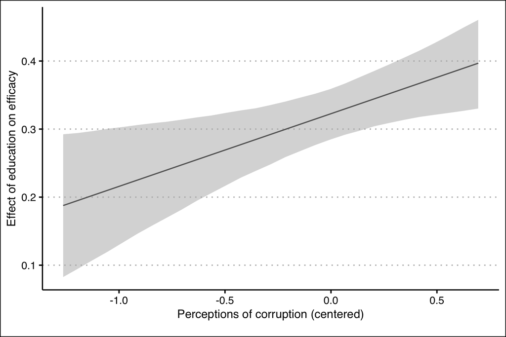

```r
graph1 +
    theme_clean() +
    labs(x = "Perceptions of corruption (centered)",
         y = "Effect of education on efficacy")
```

This makes it clear, though you would be right to doubt that more than a few readers from a non-academic background would be able to interpret this plot. If writing for a less specialized audience (a blog post, a report), it might be more fruitful to present quantities that are easier to grasp.

Showing predicted values gets us one step closer to the ideal of accessibility.

```r
dat1 <- ggpredict(mlm.3,
                  terms = c("educCWC", "cpiCGM [-1.2, -0.6, 0, 0.6]"),
                  ci.lvl = 0.95,
                  type = "fe")
```

The first variable in the list of terms is the focal independent, while the second one is the moderator variable. Here, I specify distinct values for the moderator. I specify that predictions should be conditional only on fixed-effects parameters and their uncertainty.

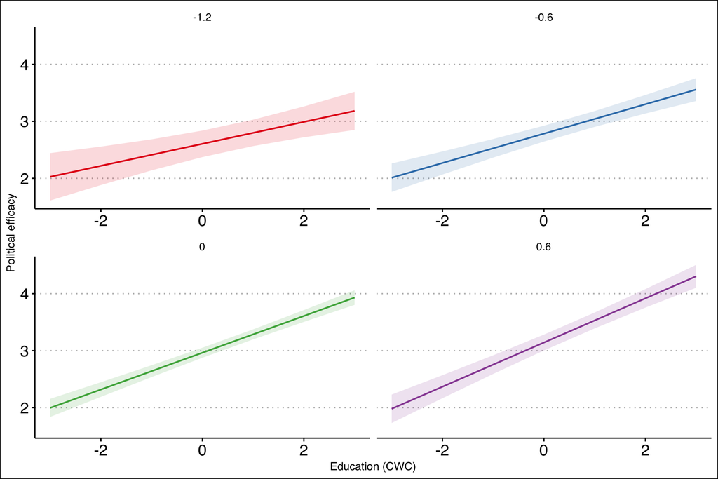

```r
plot(dat1,
     facet = TRUE,
     show.title = FALSE,
     show.x.title = FALSE,
     show.y.title = FALSE) +
  theme_clean() +
  scale_x_continuous(name = "Education (CWC)") +
  scale_y_continuous(name = "Political efficacy") +
  theme(axis.text.x = element_text(size = 14),
        axis.text.y = element_text(size = 14))
```

Unfortunately, using the canned `plot()` function gives you only a minimum amount of flexibility. If you want full control over how the plot looks, you have to access directly the quantities stored in the `dat1` object.

```r
dat1$group <- as.character(dat1$group)
dat1 <- dat1 %>%
    # Recode group label
    mutate(group = case_when(group == "-1.2" ~ "Very low (-1.2 SD)",
                             group == "-0.6" ~ "Low (-0.6 SD)",
                             group == "0" ~ "Average (0 SD)",
                             group == "0.6" ~ "High (0.6 SD)"))
# Order the levels, so that in the facet plot these are listed in order.
dat1$group <- factor(dat1$group, levels = c("Very low (-1.2 SD)", "Low (-0.6 SD)",
                                            "Average (0 SD)", "High (0.6 SD)"))
```

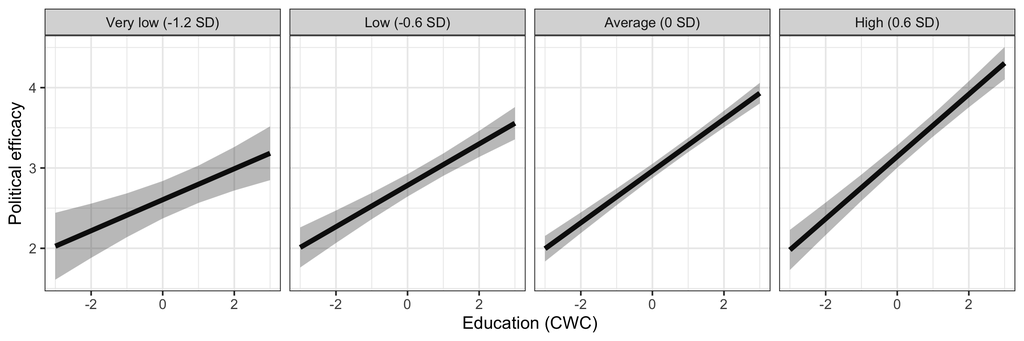

```r
ggplot(dat1,
       aes(x = x,
           y = predicted)) +
    geom_line(linewidth = 1.5) +
    geom_ribbon(aes(ymin = conf.low,
                    ymax = conf.high),
                alpha = 0.33) +
    # The "ribbon" is the shaded area around the line that denotes
    # uncertainty.
    facet_wrap(.~group, ncol = 4) +
    labs(x = "Education (CWC)",
         y = "Political efficacy") +
    theme_bw()
```

# 5 Package versions